# Análise evolução COVID-19 Brasil

Letícia Rossaneis Antunes da Silva

29/06/2020

```r
#Pacotes a serem usados
library(ggplot2)
library(gridExtra)
library(dplyr)
library(readxl)
library(patchwork)
```

Os dados a serem usados são do dia 29/06/2020.  
Vamos carregar os dados e exibir as primeiras linhas.

```r
#Banco de dados
corona = read_excel("HIST_PAINEL_COVIDBR_29jun2020.xlsx",
                                            col_types = c("text",    # Regiao
                                                          "text",    # Estado
                                                          "text",    # Municipio
                                                          "text",    # coduf
                                                          "numeric", # codmun
                                                          "numeric", # codRegiaoSaude
                                                          "text",    # nomeRegiaoSaude
                                                          "date",    # data
                                                          "numeric", # semanaEpi
                                                          "text",    # populacaoTCU2019
                                                          "numeric", # casosAcumulado
                                                          "numeric", # casosNovos
                                                          "numeric", # obitosAcumulado
                                                          "numeric", # obitosNovos
                                                          "numeric", # Recuperadosnovos
                                                          "numeric", # emAcompanhamentoNovos
                                                          "numeric"  # FgMetro
                                                          ))

head(corona)
```

```
## # A tibble: 6 x 17
##   regiao estado municipio coduf codmun codRegiaoSaude nomeRegiaoSaude
##   <chr>  <chr>  <chr>     <chr>  <dbl>          <dbl> <chr>
## 1 Brasil <NA>   <NA>      76        NA             NA <NA>
## 2 Brasil <NA>   <NA>      76        NA             NA <NA>
## 3 Brasil <NA>   <NA>      76        NA             NA <NA>
## 4 Brasil <NA>   <NA>      76        NA             NA <NA>
## 5 Brasil <NA>   <NA>      76        NA             NA <NA>
## 6 Brasil <NA>   <NA>      76        NA             NA <NA>
## # ... with 10 more variables: data <dttm>, semanaEpi <dbl>,
## #   populacaoTCU2019 <chr>, casosAcumulado <dbl>, casosNovos <dbl>,
## #   obitosAcumulado <dbl>, obitosNovos <dbl>, Recuperadosnovos <dbl>,
## #   emAcompanhamentoNovos <dbl>, FgMetro <dbl>
```

Inicialmente analisaremos a quantidade de casos e óbitos nas 100 cidades com as maiores populações do país. Para isso, iremos agrupar os dados de população de cada município e Estado e, em seguida, analisar as maiores cidades.  
As cidades de São Paulo e Rio de Janeiro (maiores populações do país) serão excluídas dessa lista com a finalidade de melhorar a visualização dos dados pois estas apresentam população e número de casos e óbitos muito mais elevados que as outras.  
Podemos analisar a relação entre população e casos ou óbitos. O gráfico de casos é mais linear, porém esse não é o melhor fator para determinar o comportamento do vírus, como podemos ver no gráfico de óbitos.

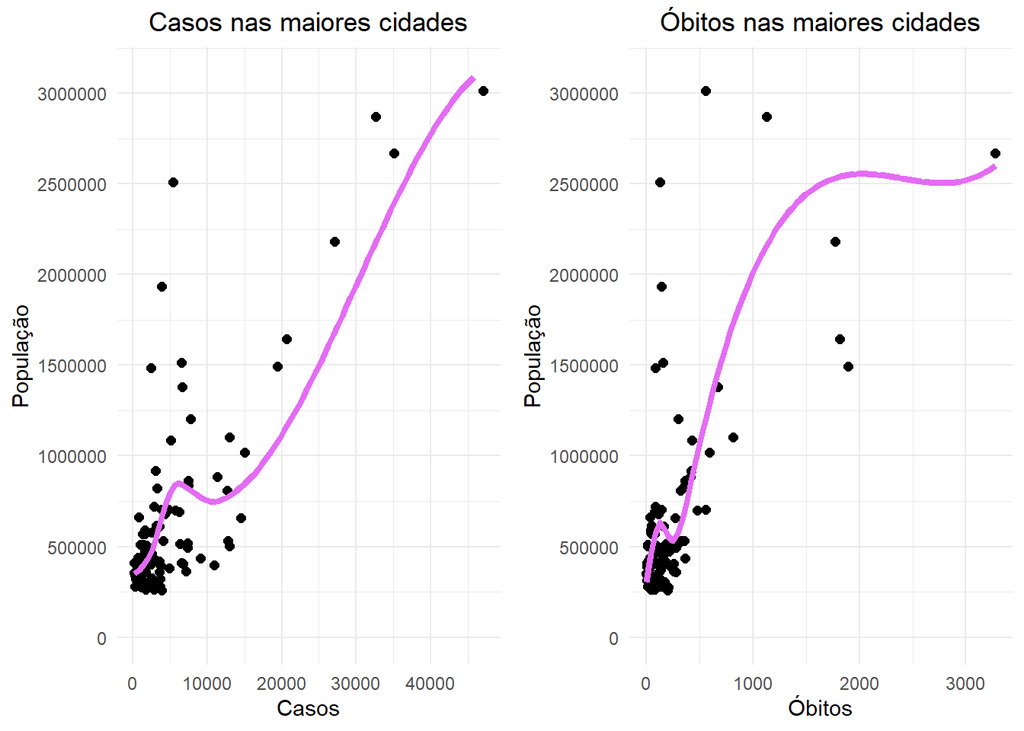

```r
#Separação da população total de cada município e estado para usar posteriormente
populacao <- filter(corona, !is.na(municipio)) %>%
  group_by(municipio) %>%
  summarize(populacao = suppressWarnings(as.numeric(populacaoTCU2019[1])))

#Casos e óbitos nos municípios com maiores populações
maior_pop <- corona %>% filter(!is.na(municipio)) %>%
  group_by(municipio) %>%
  summarize(total_casos = sum(casosNovos), total_obitos = sum(obitosNovos)) %>%
  mutate(populacao = populacao$populacao) %>%
  arrange(desc(populacao)) %>%
  #As duas cidades com maior população (São Paulo e Rio de Janeiro foram excluídas com o intuito de melorar a visualização dos dados das outras 100 cidades)
  slice(3:102)

p1 <- ggplot(maior_pop, aes(x = total_casos, y = populacao)) +
  geom_point(size = 2) +
  geom_smooth(se = FALSE, method = "loess", formula = "y ~ x", color = "#e46cf4", size = 1.5) +
  scale_y_continuous(breaks = seq(0, 3500000, 500000), limits = c(0, 3100000)) +
  labs(title = "Casos nas maiores cidades", x = "Casos", y = "População") +
  theme_minimal() +
  theme(plot.title = element_text(hjust = 0.5))

p2 <- ggplot(maior_pop, aes(x = total_obitos, y = populacao)) +
  geom_point(size = 2) +
  geom_smooth(se = FALSE, method = "loess", formula = "y ~ x", color = "#e46cf4", size = 1.5) +
  scale_y_continuous(breaks = seq(0, 3500000, 500000), limits = c(0, 3100000)) +
  labs(title = "Óbitos nas maiores cidades", x = "Óbitos", y = "População") +
  theme_minimal() +
  theme(plot.title = element_text(hjust = 0.5))

suppressWarnings(grid.arrange(p1, p2, ncol = 2))
```

Em seguida, vamos separar os dados por regiões e observar o crescimento de casos em cada uma.

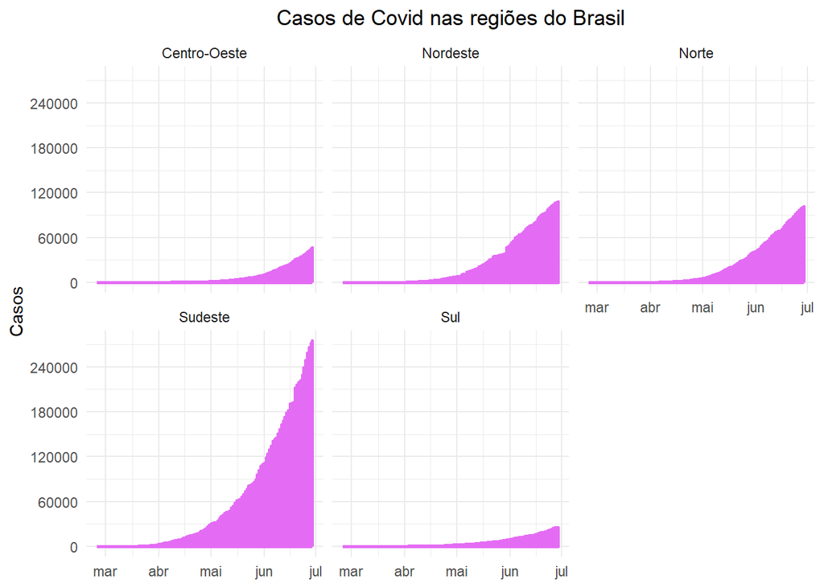

```r
regioes <- corona %>% filter(regiao != "Brasil", is.na(municipio))

ggplot(regioes, aes(x = data, y = casosAcumulado)) +
  geom_line(color = "#e46cf4", size = 1) +
  scale_y_continuous(breaks = seq(0, 280000, 60000)) +
  labs(title = "Casos de Covid nas regiões do Brasil", y = "Casos") +
  theme_minimal() +
  theme(axis.title.x = element_blank(),
        plot.title = element_text(hjust = 0.5)) +
  facet_wrap(~ regiao)
```

É bem evidente que a região mais afetada foi o Sudeste. Veremos agora o estado com mais casos:

```r
sudeste <- corona %>%
  filter(regiao == "Sudeste", is.na(municipio)) %>%
  group_by(estado) %>%
  summarize(casos = sum(casosNovos)) %>%
  arrange(desc(casos))

#Mudar nomes das colunas
colnames(sudeste) = c("Estado", "Casos")

sudeste
```

```
## # A tibble: 4 x 2
##   Estado  Casos
##   <chr>   <dbl>
## 1 SP     275195
## 2 RJ     111883
## 3 ES      45562
## 4 MG      44252
```

```r
#Filtrar estado de SP mostrando casos e óbitos por regiões
regioes_sp <- corona %>%
  filter(!is.na(municipio), estado == "SP") %>%
  group_by(nomeRegiaoSaude) %>%
  summarize(total_casos = sum(casosNovos), total_obitos = sum(obitosNovos))

#Top 10 das regiões com mais casos
top10_regioes_sp <- top_n(regioes_sp %>% arrange(desc(total_casos)), 10)
```

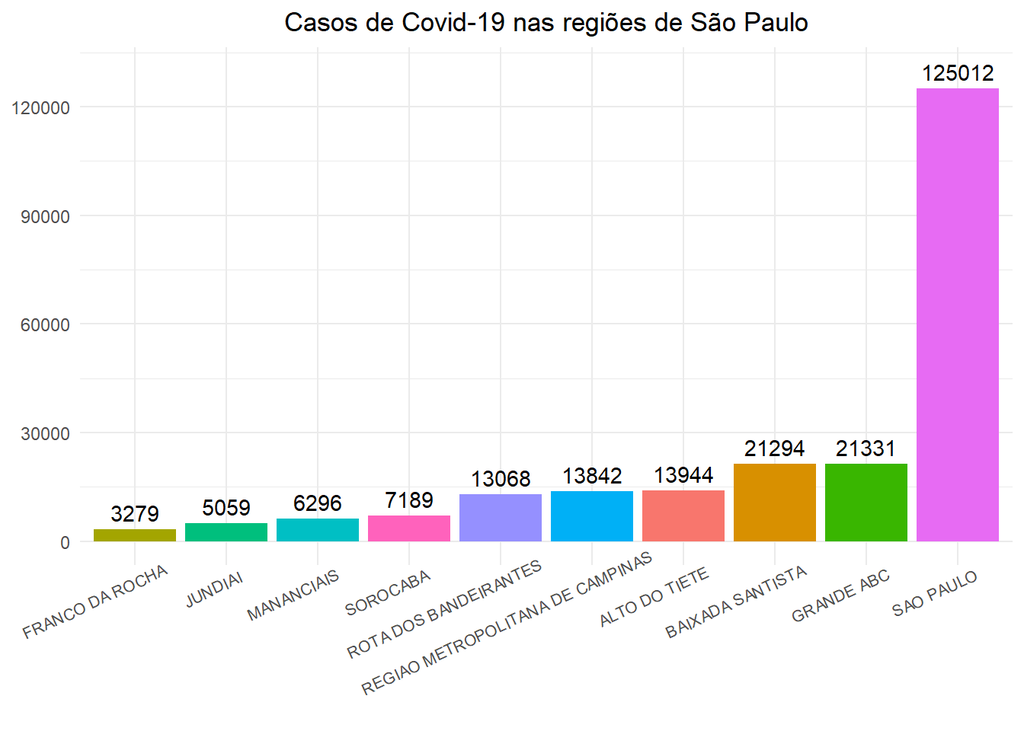

```r
ggplot(top10_regioes_sp, aes(x = reorder(nomeRegiaoSaude, total_casos), y = total_casos)) +
  geom_bar(stat = "identity", aes(fill = nomeRegiaoSaude)) +
  geom_text(aes(label = total_casos), vjust = -0.5) +
  scale_y_continuous(breaks = seq(0, 130000, 30000), limits = c(0, 130000)) +
  labs(title = "Casos de Covid-19 nas regiões de São Paulo") +
  theme_minimal() +
  theme(axis.text.x = element_text(angle = 25, hjust = 0.8, size = 8),
        axis.title = element_blank(),
        legend.position = "none",
        plot.title = element_text(hjust = 0.5))
```

Ainda no estado de São Paulo, faremos uma análise da região de Sorocaba.

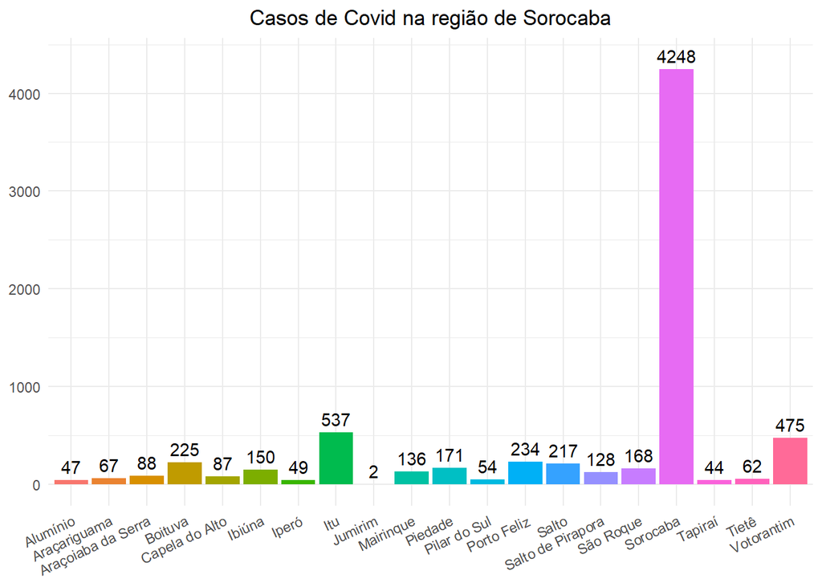

```r
#Região de Sorocaba
regiao_sorocaba <- corona %>% filter(nomeRegiaoSaude == "SOROCABA") %>%
  group_by(municipio) %>%
  summarize(total_casos = sum(casosNovos), total_obitos = sum(obitosNovos))

ggplot(regiao_sorocaba, aes(x = municipio, y = total_casos)) +
  geom_bar(stat = "identity", aes(fill = municipio)) +
  geom_text(aes(label = total_casos), vjust = -0.5) +
  scale_y_continuous(limits = c(0, 4350)) +
  theme_minimal() +
  labs(title = "Casos de Covid na região de Sorocaba") +
  theme(axis.text.x = element_text(angle = 25, hjust = 1),
        axis.title = element_blank(),
        legend.position = "none",
        plot.title = element_text(hjust = 0.5))
```

Vamos visualizar agora a evolução no número de casos e óbitos na cidade de Sorocaba.

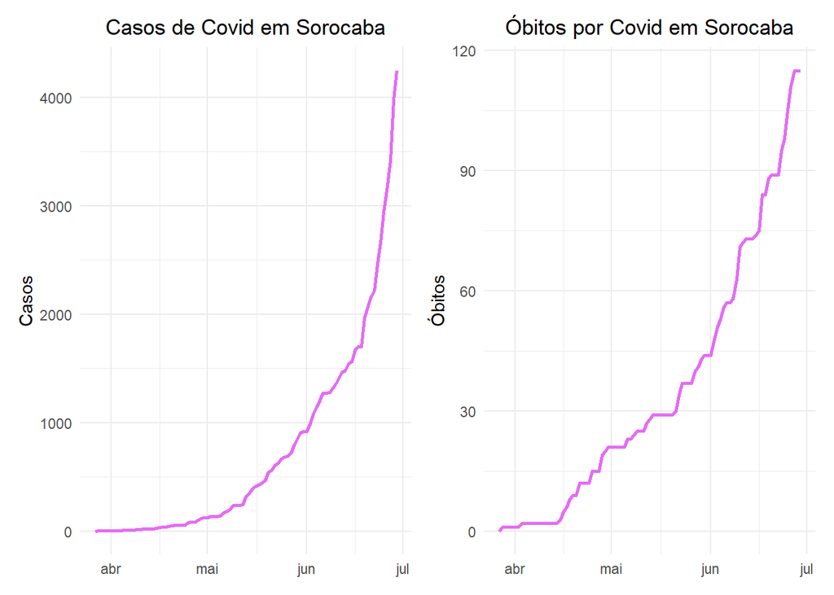

```r
#Evolução de casos e óbitos em Sorocaba
evol_sorocaba <- corona %>%
  select(municipio, casosAcumulado, obitosAcumulado, data) %>%
  filter(municipio == "Sorocaba")

#DEIXAR BONITO
casos_sor <- ggplot(evol_sorocaba, aes(x = data, y = casosAcumulado)) +
  geom_line(color = "#e46cf4", size = 1) +
  labs(title = "Casos de Covid em Sorocaba", y = "Casos") +
  theme_minimal() +
  theme(axis.title.x = element_blank(),
        plot.title = element_text(hjust = 0.5))

obitos_sor <- ggplot(evol_sorocaba, aes(x = data, y = obitosAcumulado)) +
  geom_line(color = "#e46cf4", size = 1) +
  labs(title = "Óbitos por Covid em Sorocaba", y = "Óbitos") +
  theme_minimal() +
  theme(axis.title.x = element_blank(),
        plot.title = element_text(hjust = 0.5))

casos_sor + obitos_sor
```

Vários fatores podem contribuir ou não para o controle do vírus. Observaremos os casos agora nas cinco cidades com os maiores IDHs do país.

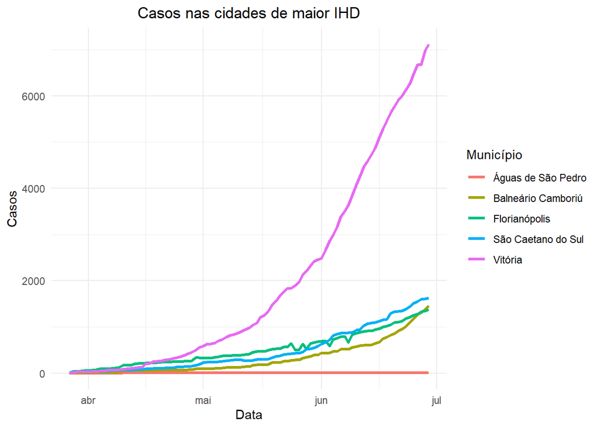

```r
#Cidades com os maiores IDHs do país
idh <- c("São Caetano do Sul", "Águas de São Pedro", "Florianópolis", "Balneário Camboriú", "Vitória")

#Casos acumulados nas 5 cidades com maior IDH
casos_idh <- corona %>% filter(municipio %in% idh) %>%
  group_by(municipio, data) %>%
  summarize(total_casos = casosAcumulado)

ggplot(casos_idh, aes(x = data, y = total_casos, color = municipio)) +
  geom_line(size = 1.2) +
  labs(title = "Casos nas cidades de maior IHD", x = "Data", y = "Casos", color = "Município") +
  theme_minimal() +
  theme(plot.title = element_text(hjust = 0.5))
```

E agora os óbitos:

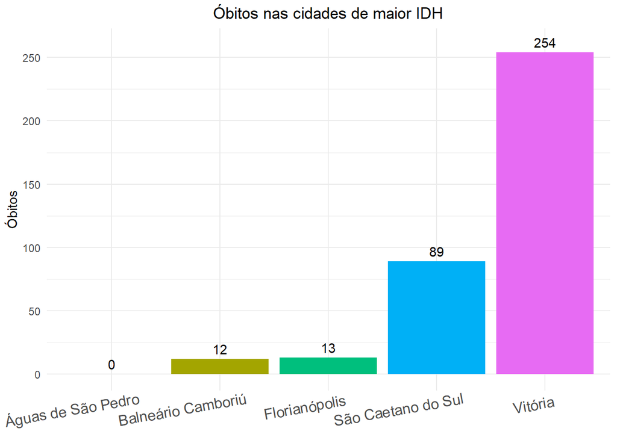

```r
#Óbitos acumulados nas 5 cidades com maior IDH
obitos_idh <- corona %>% filter(municipio %in% idh) %>%
  group_by(municipio) %>%
  summarize(total_obitos = sum(obitosNovos))

ggplot(obitos_idh, aes(x = reorder(municipio, total_obitos), y = total_obitos)) +
  geom_bar(stat = "identity", aes(fill = municipio)) +
  geom_text(aes(label = total_obitos), vjust = -0.5) +
  scale_y_continuous(breaks = seq(0, 300, 50), limits = c(0, 260)) +
  labs(title = "Óbitos nas cidades de maior IDH", y = "Óbitos") +
  theme_minimal() +
  theme(axis.text.x = element_text(angle = 10, hjust = 0.8, size = 12),
        axis.title.x = element_blank(),
        legend.position = "none",
        plot.title = element_text(hjust = 0.5))
```

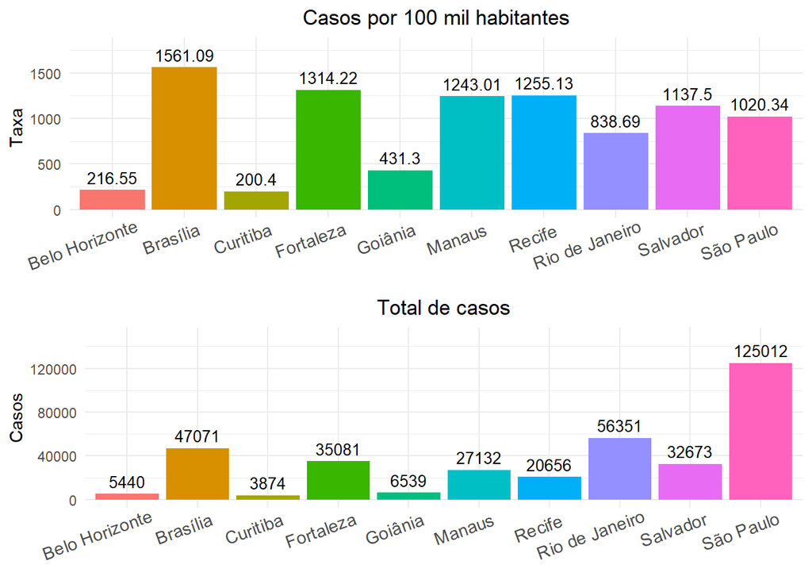

```r
#10 maiores cidades do país
cidades <- c("São Paulo", "Rio de Janeiro", "Brasília", "Salvador", "Fortaleza", "Belo Horizonte", "Manaus", "Curitiba", "Recife", "Goiânia")

#Taxa de casos e óbitos por 100mil habitantes por município
taxa_munic <- corona %>%
  filter(!is.na(municipio)) %>%
  group_by(municipio) %>%
  summarize(total_casos = sum(casosNovos), total_obitos = sum(obitosNovos)) %>%
  mutate(populacao = populacao$populacao, taxa_casos = total_casos / populacao * 100000, taxa_obitos = total_obitos / populacao * 100000) %>%
  filter(municipio %in% cidades)

p_taxa_m <- ggplot(taxa_munic, aes(x = municipio, y = taxa_casos)) +
  geom_bar(stat = "identity", aes(fill = municipio)) +
  geom_text(aes(label = round(taxa_casos, 2)), vjust = -0.5, size = 3.5) +
  scale_y_continuous(breaks = seq(0, 1800, 500), limits = c(0, 1800)) +
  labs(title = "Casos por 100 mil habitantes", y = "Taxa") +
  theme_minimal() +
  theme(axis.text.x = element_text(angle = 20, hjust = 0.8, size = 11),
        axis.title.x = element_blank(),
        legend.position = "none",
        plot.title = element_text(hjust = 0.5))

p_m <- ggplot(taxa_munic, aes(x = municipio, y = total_casos)) +
  geom_bar(stat = "identity", aes(fill = municipio)) +
  geom_text(aes(label = total_casos), vjust = -0.5, size = 3.5) +
  scale_y_continuous(breaks = seq(0, 160000, 40000), limits = c(0, 150000)) +
  labs(title = "Total de casos", y = "Casos") +
  theme_minimal() +
  theme(axis.text.x = element_text(angle = 20, hjust = 0.8, size = 11),
        axis.title.x = element_blank(),
        legend.position = "none",
        plot.title = element_text(hjust = 0.5))

grid.arrange(p_taxa_m, p_m)
```